# How do students use the system?

Maarten van der Velde

# Load required packages

```r
library(dplyr)
library(lubridate)
library(tidyr)
library(forcats)
library(ggplot2)
library(scales)
library(viridis)
theme_set(theme_classic())
fig_path <- "figures for ICCM poster/usage/"
save_figs <- TRUE
```

# Load data

```r
load("../data/cogpsych_data_anon.Rdata")
```

# Add time columns

```r
d <- data %>%
  mutate(start_time = as.POSIXct(presentationStartTime / 1000, origin = "1970-01-01", tz = "Europe/Amsterdam"),
         month = as.factor(month(start_time)),
         week = as.factor(week(start_time)),
         doy = as_date(start_time),
         weekday = factor(weekdays(start_time), levels = c("Monday", "Tuesday", "Wednesday", "Thursday", "Friday", "Saturday", "Sunday")),
         hour = hour(floor_date(start_time, "hour")))
```

# Plot usage by date

The course started on 12 September, but the first RL chapters were only made available on 12 October, so use that as the starting point.

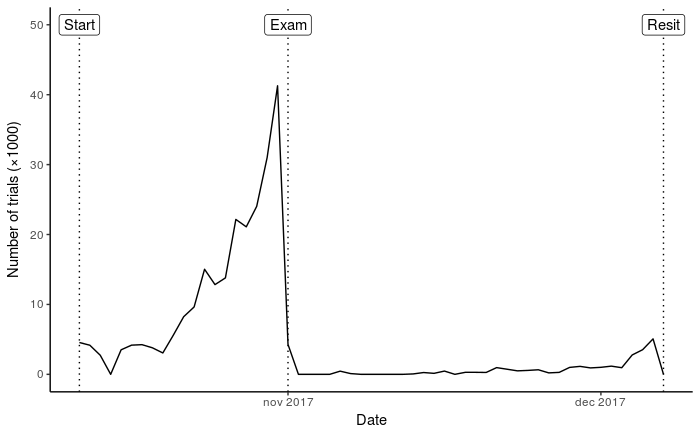

```r
start_date <- as_date("2017-09-12")
rl_available_date <- as_date("2017-10-12")
exam_date <- as_date("2017-11-01")
resit_date <- as_date("2017-12-07")
usage_by_doy <- d %>%
  group_by(doy) %>%
  tally() %>%
  ungroup() %>%
  complete(doy = seq.Date(rl_available_date, resit_date, by="day"), fill = list(n = 0)) %>%
  mutate(day_of_course = (doy - start_date))
# Absolute date
ggplot(usage_by_doy, aes(x = doy, y = n / 1000)) +
  geom_line() +
  scale_x_date(date_breaks = "1 month", date_labels = "%b %Y") +
  labs(x = "Date", y = "Number of trials (×1000)") +
  geom_vline(xintercept = c(rl_available_date, exam_date, resit_date), lty = "dotted") +
  annotate("label", x = c(rl_available_date, exam_date, resit_date), y = 50, label = c("Start", "Exam", "Resit"))
```

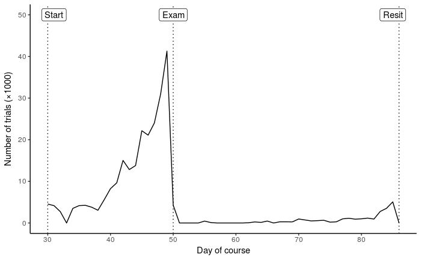

```r
# Day of course
ggplot(usage_by_doy, aes(x = day_of_course , y = n / 1000)) +
  geom_line() +
  scale_x_continuous() +
  labs(x = "Day of course", y = "Number of trials (×1000)") +
  geom_vline(xintercept = c(rl_available_date - start_date, exam_date - start_date, resit_date - start_date), lty = "dotted") +
  annotate("label", x = c(rl_available_date - start_date + 1, exam_date - start_date, resit_date - start_date - 1), y = 50, label = c("Start", "Exam", "Resit"))
if(save_figs) ggsave(paste0(fig_path, "usage_by_day_of_course.pdf"), width = 5, height = 3)
```

# Plot usage by hour of day

## Across days

The plot below shows the usage by hour averaged over the entire span of the course (a trial counts towards the hour in which it started, so a 14:59 trial counts as a 14:00 trial).

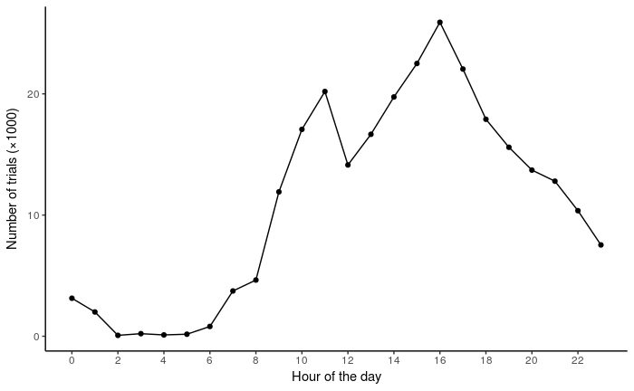

```r
usage_by_hour <- d %>%
  group_by(hour) %>%
  tally() %>%
  ungroup()
ggplot(usage_by_hour, aes(x = hour, y = n / 1000)) +
  geom_point() +
  geom_line() +
  scale_x_continuous(breaks = seq(0,23, by = 2)) +
  labs(x = "Hour of the day", y = "Number of trials (×1000)")
if(save_figs) ggsave(paste0(fig_path, "usage_by_hour_average.pdf"), width = 5, height = 3)
```

## Split by day

Since there are only 20 days between first availability of RL and the exam, we can plot usage for all days separately.

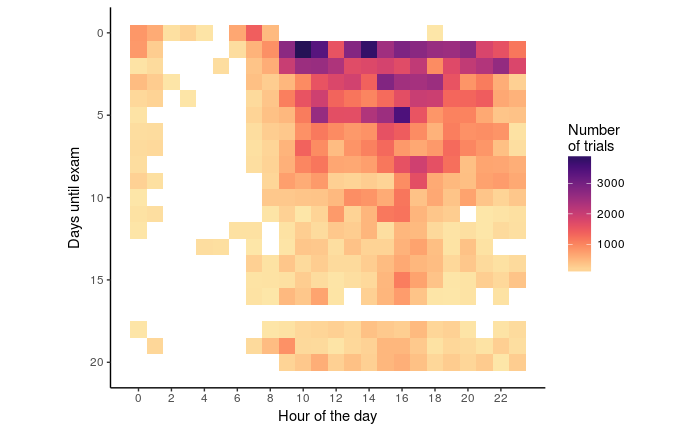

```r
usage_by_hour_of_doy <- d %>%
  filter(doy >= rl_available_date, doy <= exam_date) %>%
  group_by(doy, hour) %>%
  tally() %>%
  ungroup() %>%
  mutate(days_until_exam = exam_date - doy)
ggplot(usage_by_hour_of_doy, aes(x = hour, y = days_until_exam)) +
  geom_tile(aes(fill = n)) +
  coord_equal() +
  scale_fill_viridis(option = "magma", begin = 0.15, end = 0.95, direction = -1) +
  #scale_fill_distiller(palette = "YlOrRd", direction = 1) +
  scale_x_continuous(breaks = seq(0,23, by = 2)) +
  scale_y_reverse() +
  labs(x = "Hour of the day", y = "Days until exam") +
  guides(fill = guide_colourbar("Number\nof trials"))
if(save_figs) ggsave(paste0(fig_path, "usage_by_hour_per_day.pdf"), width = 5, height = 5)
```

## Split by weekday

[figure not shown]

```r
usage_by_hour_of_day <- d %>%
  group_by(weekday, hour) %>%
  tally() %>%
  group_by(weekday) %>%
  mutate(freq = n/sum(n)) %>%
  ungroup() %>%
  mutate(weekday = factor(weekday, levels = rev(levels(weekday))))
ggplot(usage_by_hour_of_day, aes(x = hour, y = weekday)) +
  geom_tile(aes(fill = n)) +
  coord_equal() +
  scale_fill_viridis(option = "magma", begin = 0.15, end = 0.95, direction = -1) +
  # scale_fill_distiller(palette = "YlOrRd", direction = 1) +
  scale_x_continuous(breaks = c(0:23)) +
  labs(x = "Hour of the day", y = "Day of the week") +
  guides(fill = guide_colourbar("Number\nof trials"))
if(save_figs) ggsave(paste0(fig_path, "usage_by_hour_per_weekday_summed.pdf"), width = 7, height = 5)
```

In the plot below, frequency is normalised within days (so that the sum of all hours in a day equals 1). This lets us see how learning is distributed within a day, but does not allow direct comparison between days (points with the same colour do not necessarily have the same absolute study frequency, only the same relative frequency within their respective days).

[figure not shown]

```r
ggplot(usage_by_hour_of_day, aes(x = hour, y = weekday)) +
  geom_tile(aes(fill = freq)) +
  coord_equal() +
  scale_fill_viridis(option = "magma", begin = 0.15, end = 0.95, direction = -1) +
  # scale_fill_distiller(palette = "YlOrRd", direction = 1) +
  scale_x_continuous(breaks = c(0:23)) +
  labs(x = "Hour of the day", y = "Day of the week") +
  guides(fill = FALSE)
if(save_figs) ggsave(paste0(fig_path, "usage_by_hour_per_weekday_normalised.pdf"), width = 5, height = 5)
```

# Usage by learner

## Number of sessions

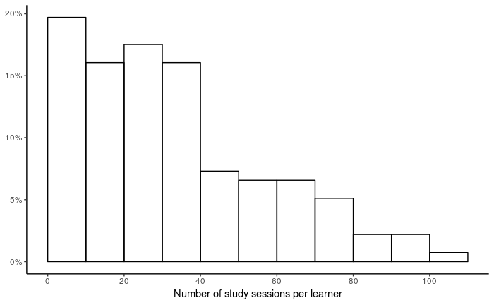

```r
session_count <- d %>%
  group_by(User) %>%
  summarise(sessions = length(unique(session)))
ggplot(session_count, aes(x = sessions)) +
  geom_histogram(aes(y = ..count../sum(..count..)), breaks = seq(0, max(session_count$sessions), by = 10), colour = "black", fill = NA) +
  labs(x = "Number of study sessions per learner", y = NULL) +
  scale_x_continuous(breaks = seq(0, max(session_count$sessions), by = 20)) +
  scale_y_continuous(labels = percent)
if(save_figs) ggsave(paste0(fig_path, "session_count_histogram.pdf"), width = 5, height = 3)
```

What proportion of learners completed only a single session?

```r
session_count %>%
  filter(sessions == 1) %>%
  nrow() / nrow(session_count)
```

```
[1] 0.04347826
```

## Number of trials

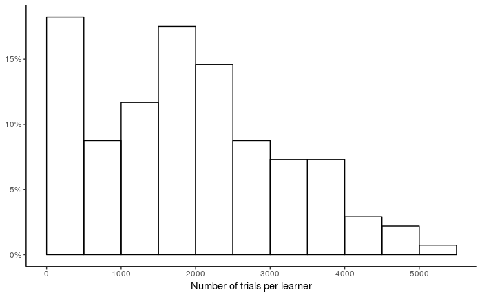

```r
trial_count <- d %>%
  group_by(User) %>%
  summarise(trials = n())
ggplot(trial_count, aes(x = trials)) +
  geom_histogram(aes(y = ..count../sum(..count..)), breaks = seq(0, max(trial_count$trials), by = 500), colour = "black", fill = NA) +
  labs(x = "Number of trials per learner", y = NULL) +
  scale_x_continuous(breaks = seq(0, 5000, by = 1000)) +
  scale_y_continuous(labels = percent)
if(save_figs) ggsave(paste0(fig_path, "trial_count_histogram.pdf"), width = 5, height = 3)
```

# Session length

## Number of trials

The histogram below shows that there is a narrow peak close to zero (users who start a session and immediately stop) and a wider peak to its right.

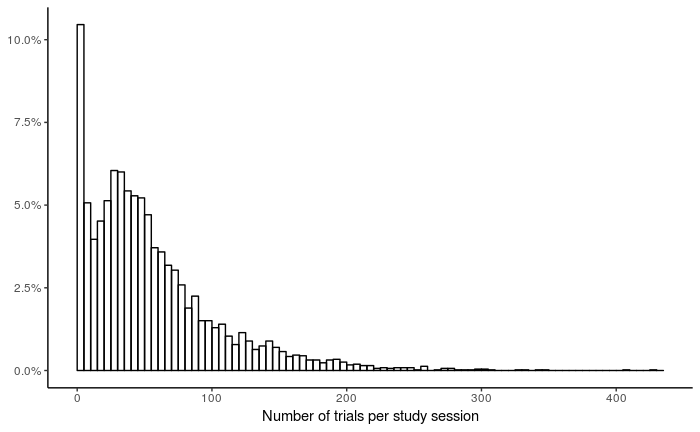

```r
session_length <- d %>%
  group_by(User, session) %>%
  summarise(duration = (max(presentationStartTime) - min(presentationStartTime)) / (60 * 1000),
            trials = n())
ggplot(session_length, aes(x = trials)) +
  geom_histogram(aes(y = ..count../sum(..count..)), breaks = seq(0, max(session_length$trials), by = 5), colour = "black", fill = NA) +
  labs(x = "Number of trials per study session", y = NULL) +
  scale_x_continuous(breaks = seq(0, max(session_length$trials), by = 100)) +
  scale_y_continuous(labels = percent)
if(save_figs) ggsave(paste0(fig_path, "trials_per_session_histogram.pdf"), width = 5, height = 3)
```

```r
NA
```

## Duration

Users can specify beforehand how long their session should be. Some session durations stand out in the histogram, in particular 8 minutes (the default duration) and 5 minutes, but there are also distinct peaks at multiples of 8 (16, 24, 32, 40) and multiples of 10 (10, 20, 30). This regularity suggests that users have a tendency to finish a session once they have started.

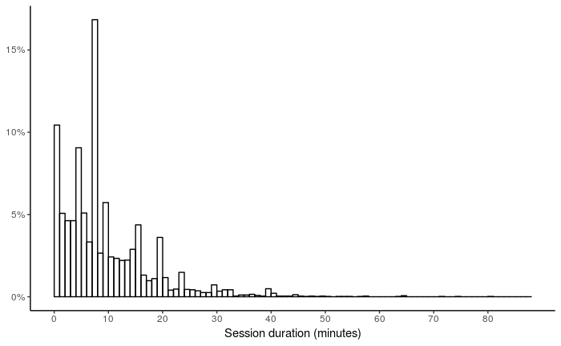

```r
ggplot(session_length, aes(x = duration)) +
  geom_histogram(aes(y = ..count../sum(..count..)), breaks = seq(0, max(session_length$duration), by = 1), colour = "black", fill = NA) +
  labs(x = "Session duration (minutes)", y = NULL) +
  scale_x_continuous(breaks = seq(0, max(session_length$duration), by = 10)) +
  scale_y_continuous(labels = percent)
if(save_figs) ggsave(paste0(fig_path, "session_duration_histogram.pdf"), width = 5, height = 3)
```

# Session spacing

How did students spread out their learning over the course?

## Intervals between sessions

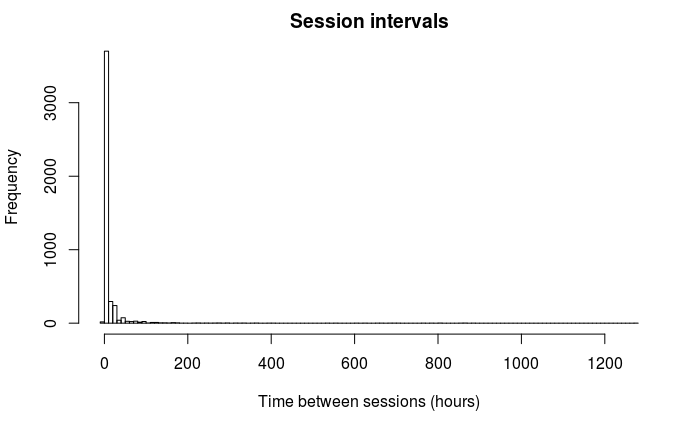

```r
session_spacing <- d %>%
  group_by(User) %>%
  filter(length(unique(session)) > 1) %>% # Filter out users with only one session
  group_by(User, session) %>%
  summarise(session_start = min(start_time),
            session_end = max(start_time) + if_else(
              is.na(reactionTime[which.max(start_time)]),
              median(d$reactionTime, na.rm = TRUE) / 1000,
              reactionTime[which.max(start_time)] / 1000)) %>%
  group_by(User) %>%
  mutate(session_interval = session_start - lag(session_end)) %>%
  filter(!is.na(session_interval)) %>% # Leave out the non-existent interval leading up to a user's first session
  mutate(session_interval_simple = case_when(
    session_interval <= 1 * 60 ~ "1 minute",
    session_interval <= 10 * 60 ~ "10 minutes",
    session_interval <= 60 * 60 ~ "1 hour",
    session_interval <= 24 * 60 * 60 ~ "1 day",
    session_interval <= 7 * 24 * 60 * 60 ~ "1 week",
    TRUE ~ "longer"
  )) %>%
  ungroup() %>%
  mutate(session_interval_simple = fct_relevel(as.factor(session_interval_simple), "1 minute", "10 minutes", "1 hour", "1 day", "1 week", "longer"))
hist(as.numeric(session_spacing$session_interval) / 3600, 100, xlab = "Time between sessions (hours)", main = "Session intervals")
```

```r
summary(as.numeric(session_spacing$session_interval) / 3600)
```

```
     Min.   1st Qu.    Median      Mean   3rd Qu.      Max.
  -0.0664    0.0175    0.1238   11.9472    2.8312 1279.1777
```

Unsurprisingly, the time intervals between a user's sessions have a massively skewed distribution.

We can get a more interpretable representation of the intervals by discretising. The table below shows the cumulative proportion of session intervals that fall within a certain time range. It indicates that users are inclined to batch their learning sessions together: almost a quarter of sessions start within 1 minute of the end of the previous session, and over half start within 10 minutes. Only about 10% of session-to-session intervals are longer than 24 hours.

```r
cumsum(table(session_spacing$session_interval_simple)/nrow(session_spacing))
```

```
  1 minute 10 minutes     1 hour      1 day     1 week     longer
 0.2398427  0.5286151  0.6732197  0.9082569  0.9882045  1.0000000
```

## Total practice span

How much time is there between the first and last moment of study for each user?

```r
session_span <- session_spacing %>%
  group_by(User) %>%
  summarise(start = min(session_start),
            end = max(session_end),
            total_span = max(session_end) - min(session_start)) %>%
  mutate(start_doc = as_date(start) - start_date,
         end_doc = as_date(end) - start_date) %>%
  left_join(grades, by = "User") %>%
  arrange(start)
```

```
Column `User` joining factor and character vector, coercing into character vector
```

Plot the total study range (time from start of first session to end of last session) per user:

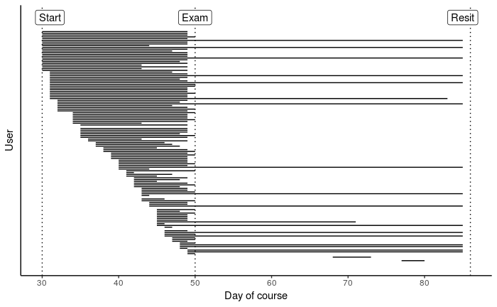

```r
ggplot(session_span, aes(y = end_doc, ymin = start_doc, ymax = end_doc, x = sort(User, decreasing = TRUE))) +
  scale_x_discrete(expand = c(0.05, 0)) +
  geom_linerange(position = position_dodge(1), lwd = 0.5) +
  scale_y_continuous() +
  coord_flip() +
    geom_hline(yintercept = c(rl_available_date - start_date, exam_date - start_date, resit_date - start_date), lty = "dotted") +
  annotate("label", y = c(rl_available_date - start_date + 1, exam_date - start_date, resit_date - start_date - 1), x = 140, label = c("Start", "Exam", "Resit")) +
  labs(x = "User", y = "Day of course") +
  theme(axis.text.y=element_blank(),
        axis.ticks.y=element_blank())

if(save_figs) ggsave(paste0(fig_path, "first_and_last_usage.pdf"), width = 5, height = 3)
```

Colour each user's line based on their final grade in the course:

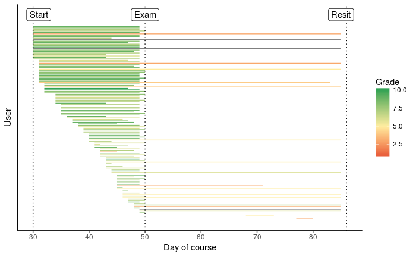

```r
ggplot(session_span, aes(y = end_doc, ymin = start_doc, ymax = end_doc, x = sort(User, decreasing = TRUE), colour = Grade)) +
  scale_x_discrete(expand = c(0.05, 0)) +
  geom_linerange(position = position_dodge(1), lwd = 0.5) +
  scale_y_continuous() +
  scale_color_gradient2(low = "#de2d26", high = "#31a354", mid = "#ffeda0", midpoint = 5) +
  coord_flip() +
    geom_hline(yintercept = c(rl_available_date - start_date, exam_date - start_date, resit_date - start_date), lty = "dotted") +
  annotate("label", y = c(rl_available_date - start_date + 1, exam_date - start_date, resit_date - start_date - 1), x = 140, label = c("Start", "Exam", "Resit")) +
  labs(x = "User", y = "Day of course") +
  theme(axis.text.y=element_blank(),
        axis.ticks.y=element_blank())

if(save_figs) ggsave(paste0(fig_path, "first_and_last_usage_with_grade.pdf"), width = 5, height = 3)
```

# Question Type

The RL study questions were available as open questions (type in the answer) and as multiple choice questions (select the answer from 4 choices shown on screen), and students decided for themselves what kind of question they wanted get during a practice session (a session is either entirely open or entirely MC).

## Overall choice

In aggregate, users show a strong preference for open questions (about 4 in every 5 sessions) over multiple choice questions (about 1 in 5 sessions):

```r
session_type <- d %>%
  mutate(type = as.factor(if_else(Number.Of.Alternatives == 1, "Open", "Multiple choice"))) %>%
  group_by(User, session, doy, type) %>%
  tally()
table(session_type$type)/nrow(session_type)
```

```
Multiple choice            Open
      0.1809725       0.8190275
```

## Choice over time

"Multiple choice" sessions are chosen at a fairly constant rate, whereas "open" sessions become much more popular as the exam gets closer:

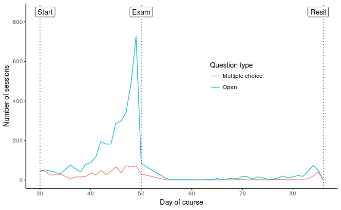

```r
session_type_over_time <- session_type %>%
  left_join(usage_by_doy, by = "doy") %>%
  group_by(doy, day_of_course, type) %>%
  summarise(n_sessions = n())
# Nobody used the system on the day of the resit, so add the final day separately
session_type_over_time <- bind_rows(session_type_over_time, data.frame(doy = rep(as_date("2017-12-07"), 2), day_of_course = as.difftime(rep(resit_date - start_date, 2), units = "days"), type = c("Multiple choice", "Open"), n_sessions = rep(0L, 2)))
ggplot(session_type_over_time, aes(x = day_of_course, y = n_sessions, colour = type)) +
  geom_line() +
  scale_x_continuous() +
  labs(x = "Day of course", y = "Number of sessions") +
  geom_vline(xintercept = c(rl_available_date - start_date, exam_date - start_date, resit_date - start_date), lty = "dotted") +
  annotate("label", x = c(rl_available_date - start_date + 1, exam_date - start_date, resit_date - start_date - 1), y = 850, label = c("Start", "Exam", "Resit")) +
  guides(colour = guide_legend("Question type")) +
  theme(legend.position = c(0.675, 0.6))
if(save_figs) ggsave(paste0(fig_path, "usage_by_day_of_course_mc_vs_open.pdf"), width = 5, height = 3)
```

Much of the practice takes place on the day before the exam:

```r
session_type_over_time %>%
  filter(doy == exam_date - 1) %>%
  pull(n_sessions) %>%
  sum() / sum(session_type_over_time$n_sessions)
```

```
[1] 0.1691332
```

## Choice by user

As the plot below shows, users are not entirely committed to choosing only open or only multiple choice sessions. Users above the diagonal line preferred multiple choice; users below the line preferred open questions.

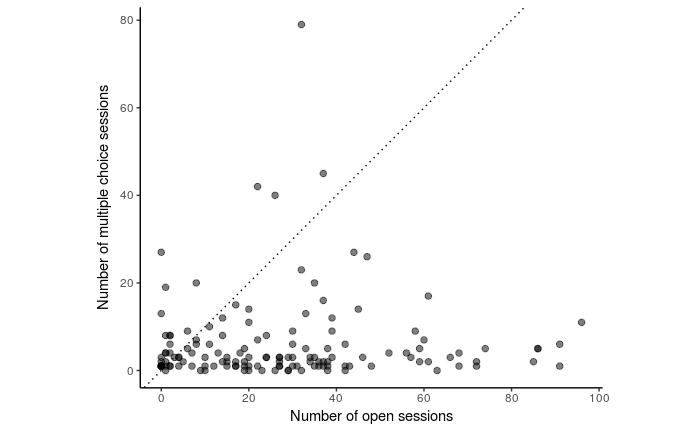

```r
session_choice_by_user <- session_type %>%
  group_by(User, type) %>%
  summarise(n_sessions = n()) %>%
  spread(type, n_sessions, fill = 0)
ggplot(session_choice_by_user, aes(x = `Open`, y = `Multiple choice`)) +
  coord_equal() +
  scale_x_continuous(breaks = seq(0, 100, 20)) +
  scale_y_continuous(breaks = seq(0, 100, 20)) +
  geom_abline(slope = 1, lty = 3) +
  geom_point(alpha = 0.5, size = 2) +
  labs(x = "Number of open sessions", y = "Number of multiple choice sessions")
if(save_figs) ggsave(paste0(fig_path, "session_count_by_user_and_type.pdf"), width = 5, height = 5)
```

Preference by user:

```r
session_choice_by_user %>%
  mutate(preferred = case_when(
    `Multiple choice` < `Open` ~ "Open",
    `Multiple choice` == `Open` ~ "Neither",
    `Multiple choice` > `Open` ~ "Multiple choice")
  ) %>%
  pull(preferred) %>%
  table()
```

```
.
Multiple choice         Neither            Open
             24               2             112
```

We can make the same plot for the number of trials rather than the number of sessions, to account for any differences in session length (which the previous plot does not show). As before, users above the diagonal line completed more multiple choice trials; users below the line answered more open questions.

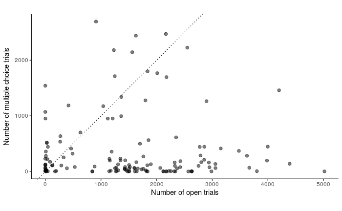

```r
session_choice_by_user_trials <- session_type %>%
  group_by(User, type) %>%
  summarise(n_trials = sum(n)) %>%
  spread(type, n_trials, fill = 0)
ggplot(session_choice_by_user_trials, aes(x = `Open`, y = `Multiple choice`)) +
  coord_equal() +
  geom_abline(slope = 1, lty = 3) +
  geom_point(alpha = 0.5, size = 2) +
  labs(x = "Number of open trials", y = "Number of multiple choice trials")
if(save_figs) ggsave(paste0(fig_path, "trial_count_by_user_and_type.pdf"), width = 5, height = 5)
```

Preference by user:

```r
session_choice_by_user_trials %>%
  mutate(preferred = case_when(
    `Multiple choice` < `Open` ~ "Open",
    `Multiple choice` == `Open` ~ "Neither",
    `Multiple choice` > `Open` ~ "Multiple choice")
  ) %>%
  pull(preferred) %>%
  table()
```

```
.
Multiple choice            Open
             31             107
```

As the plots and tables show, users strongly preferred open questions to multiple choice questions (only 24 of 138 users completed more MC sessions than open sessions; and 31 of 138 users completed more MC trials than open trials).

## Session length by type

The plots below show that both types of session have about the same number of trials, but that sessions with multiple choice questions may take a bit less time (though there are > 4x more open sessions than MC sessions, so take these comparisons with a grain of salt).

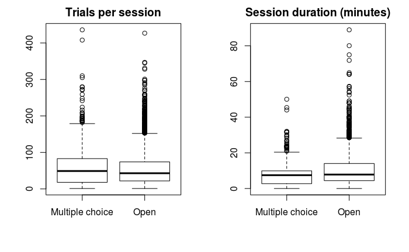

```r
session_length_by_type <- left_join(session_length, session_type, by = c("User", "session"))
par(mfrow = c(1,2))
boxplot(session_length_by_type$trials ~ session_length_by_type$type, main = "Trials per session")
boxplot(session_length_by_type$duration ~ session_length_by_type$type, main = "Session duration (minutes)")
```